# NBES calculation in simulated data

Here we analyse the model runs created to explore the underlying mechanisms in the NBES paper.

## Model description

We simulated a five-species community using a continuous Lotka-Volterra model with temperature-dependent vital rates (Vasseur, 2020). In the model, the change of biomass for each species is described as

dN_i/dt = N_i*r(T)* (1-(∑α_ij*N_j)/K(T))

where N_i is the species-specific biomass, The r is the intrinsic rate of natural increase, which is given by the difference between the birth rate (b_(0,i) ) and deathrate (d_(0,i)). K is the carrying capacity, α_(i,j) the competition strength between species i and species j, and N_j the biomass of species j.

The carrying capacity K of species i is given as K_i=r_mi/(β+δ) (Vasseur, 2020; Eq 14.6) where β and δ are the density dependent constants.

Temperature dependence was incorporated into the birth and death rate: b_(0,i) (T)=abe^(-(T-b_(opt,i) )^2/s_i ) d_(0,i) (T)=ade^ziT (Vasseur, 2020; Eq 14.5)

where, a_ is an intercept, b_(opt,i) is the temperature at which intrinsic growth rate is highest, s is the width of intrinsic growth rate, z is the slope of death rate and scales the effect of temperature (in °C) to mimic the Arrhenius relationship. Combining the birth rate temperature function and death rate temperature function gives the left-skewed shape common for temperature performance curves (Vasseur, 2020).

We created communities 5 species, that differ in their strength of interspecific competition and temperature optimum. The interspecific competition terms are drawn from a one-sided normal distribution α>0, so that all interactions were competitive with asymmetric interactions between any two species in the model. A higher value for α indicates a stronger effect by species i on species j, whereas a low value of α indicates a small effect of species i on species j. We varied interspecific competition terms by introducing differing standard deviations of competition values α_ij.

We simulated each of the species within the communities as monocultures and in combinations of 2-5 species. Each of the species assemblages was then exposed to a temperature increase (disturbance) and a control (undisturbed).

## Settings

n = 5 species;  
repetitions = 20, 20 independent simulations for each scenario;  
time points = 150;

Temp Min: 15 (minimum temperature in disturbance);  
Temp Max:20 (maximum temperature in disturbance);  
Temp Control: 17.5 (temperature for control run).

We manipulated response diversity (RD) and species competition strength (alpha). Specifically, we tested three levels of competitiveness in our communities, that were drawn from a left-sided distribution, so that all interactions are competitive:  
sd = 0 - no interaction;  
sd = 0.25 intermediate interaction strength;  
sd = 0.5 high interaction strength;

We ran 20 independent simulations for each of the settings. For analysis, we include only the first 100 time points before the system shows non-equlibrium/ chaotic dynamics

## Simulation results

### disturbance Type: Press Disturbance

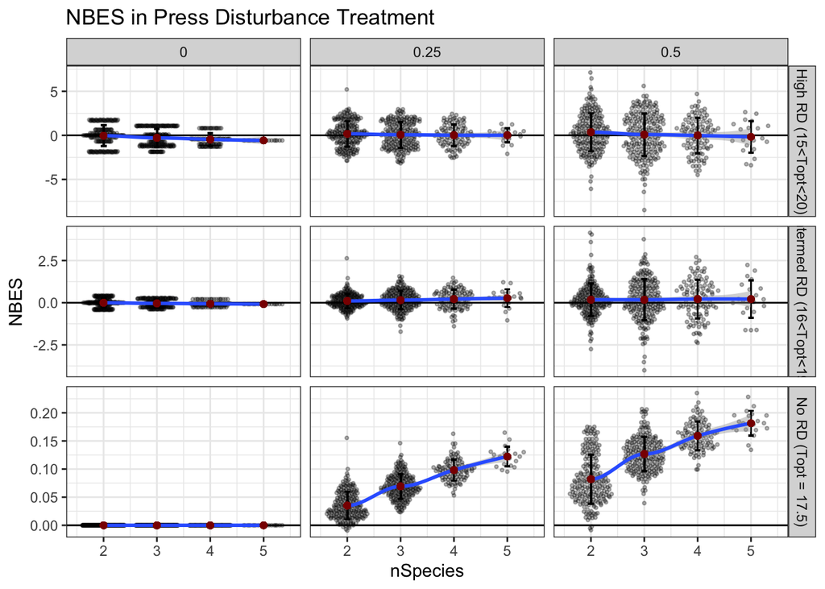

We can observe that the NBES depends on both, species competition and response diversity.

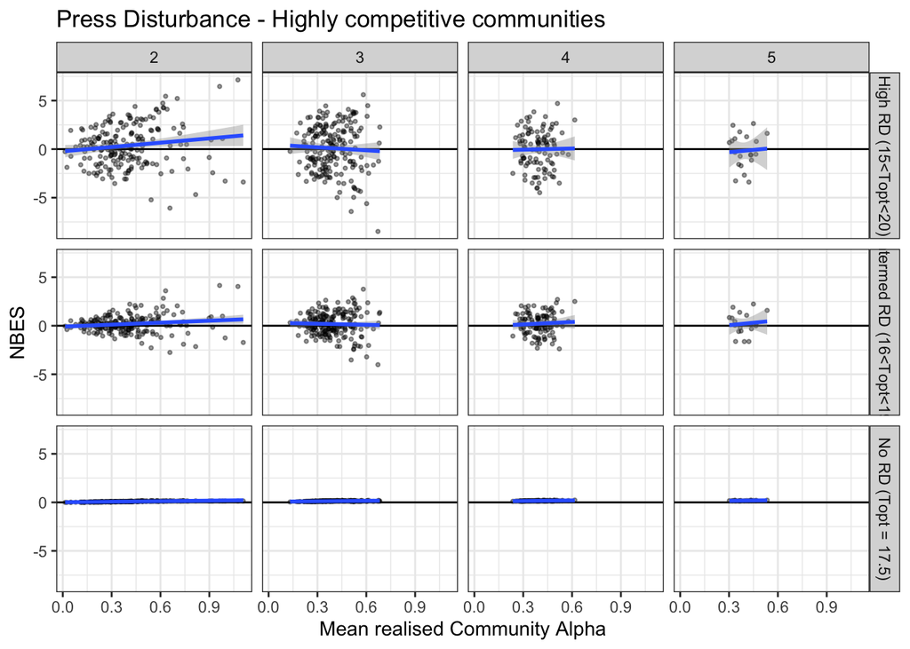

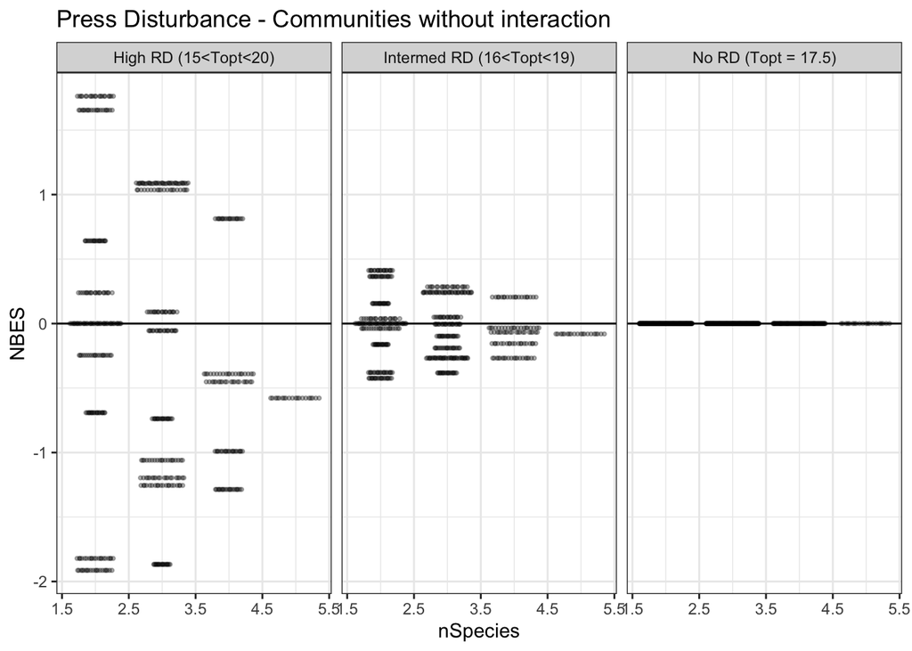

For communities without interaction (sd = 0), we observe that the NBES is zero if also the RD is low/ zero. Thus, our metric works.

### disturbance Type: Fluctuations

Next we look at diurnal fluctuations, where one fluctuation is = 1 timepoint. Minimum and Maximum temperatures are as set above.

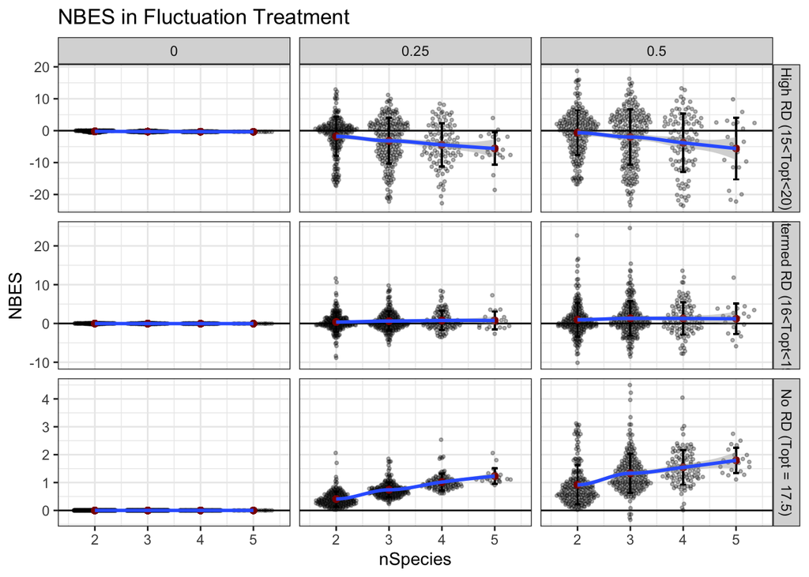

The NBES is decreasing with increasing species richness for high RD, but increases when there is no RD. This is reverse than what we would have expected. Domes explanation for this is the following: In a high RD scenario, there are always two species which have their TOpt at the minimum and maximum obtainable temperatures. The time window in our simulations for these spp to grow is small. Increasing diversity comes with a higher propability of including these ‘poor-performing’ spp in the community. If such spp are also poor competitors, their realised growth is even worse than expected from monoculture, leading to a negative NBES with increasing diversity and competition.

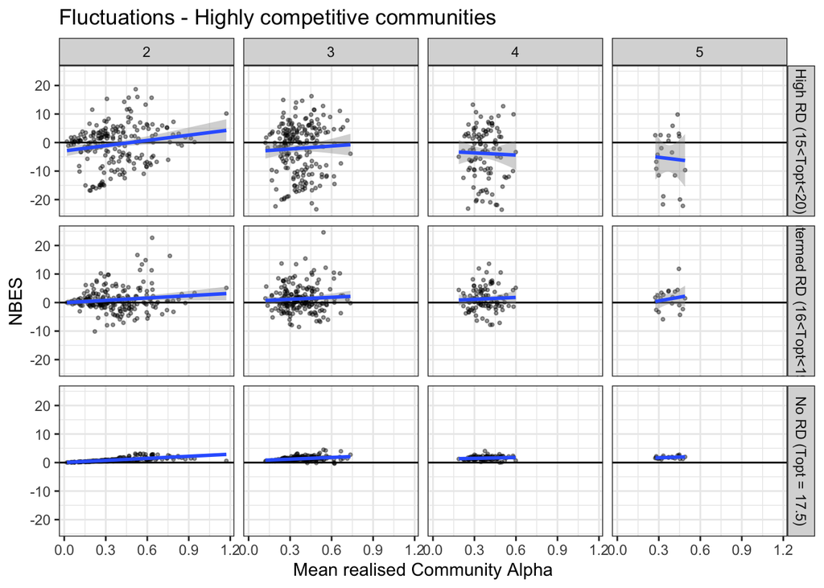

For highly competitive communities, we find that RD has a negative effect on NBES.

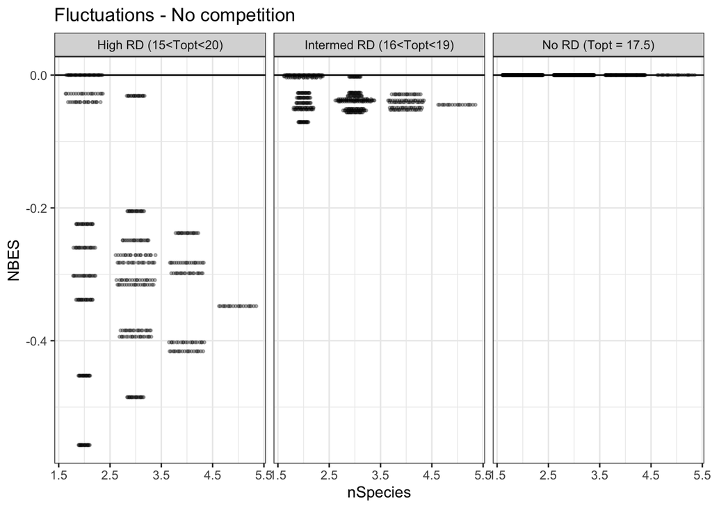

When no interaction between species occur, the NBES is negative for high RD and zero for low response diversity.

### disturbance Type: Combined Disturbances (Fluctuations and Press)

Now we take a look at the combined effects of temperature fluctuations around an increasing mean. Minimum and Maximum temperatures are as set above. Fluctuations are +- 2.5 degree around the increasing mean.

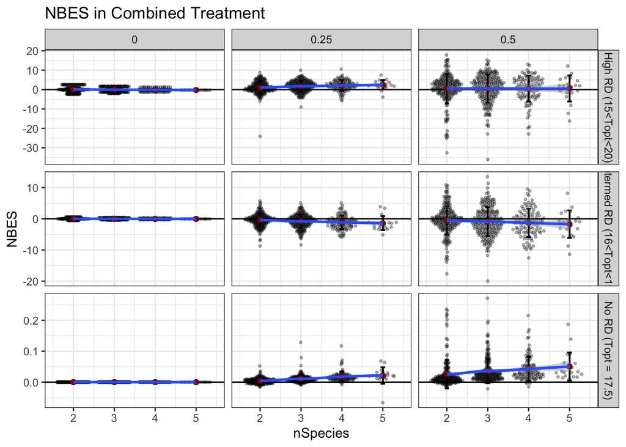

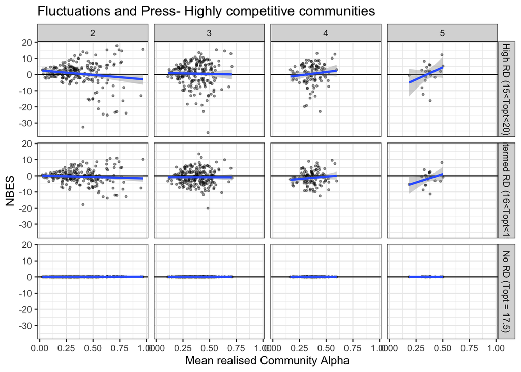

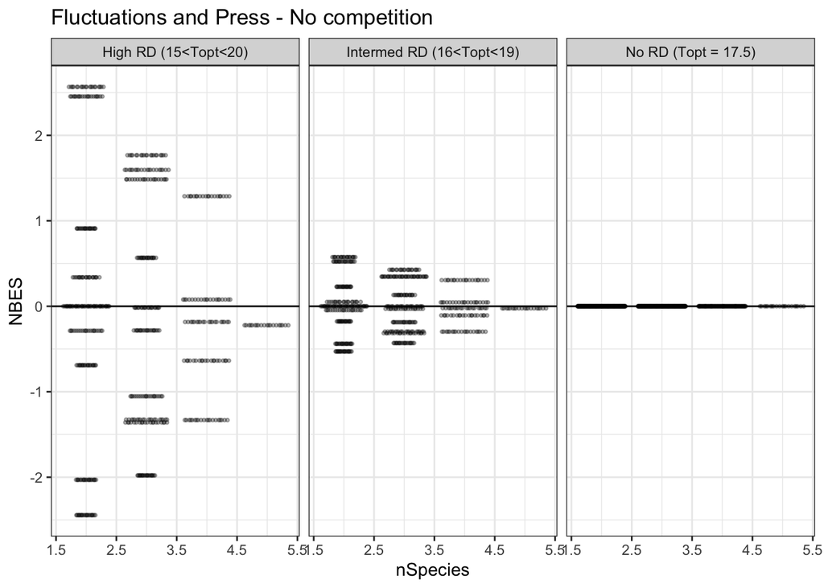

The combination of fluctuations and temperature increase (press) shows that the outcome of the NBES is highly dependend not only on the response diversity of species (variation in their Temperature Performance Curves), but also the strength of interspecific interactions. If no interactions occur, the NBES shows higher heterogeneity and greater effect sizes for high response diversity.

### Example Run - Combined disturbances

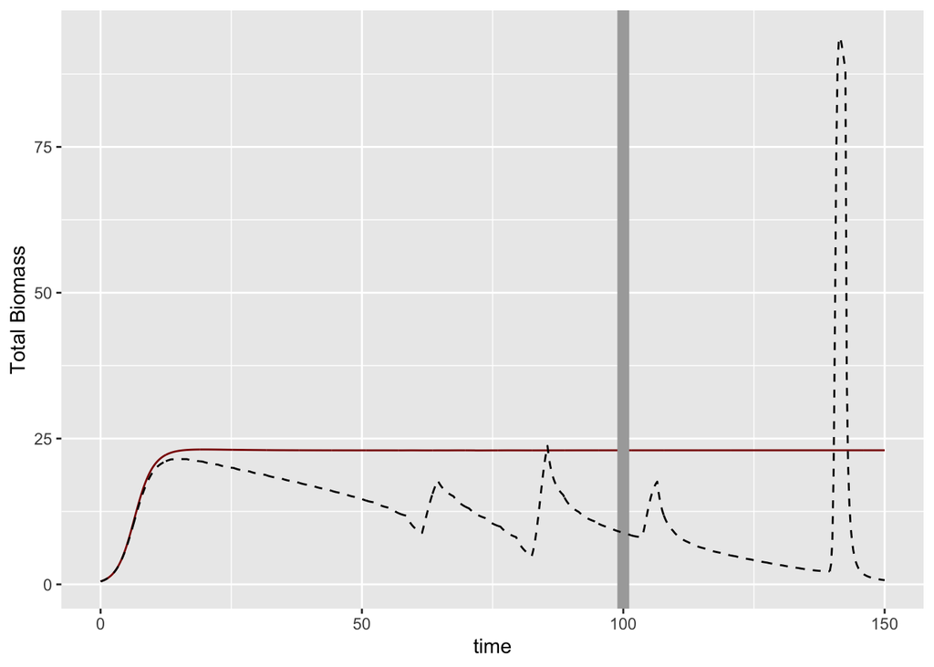

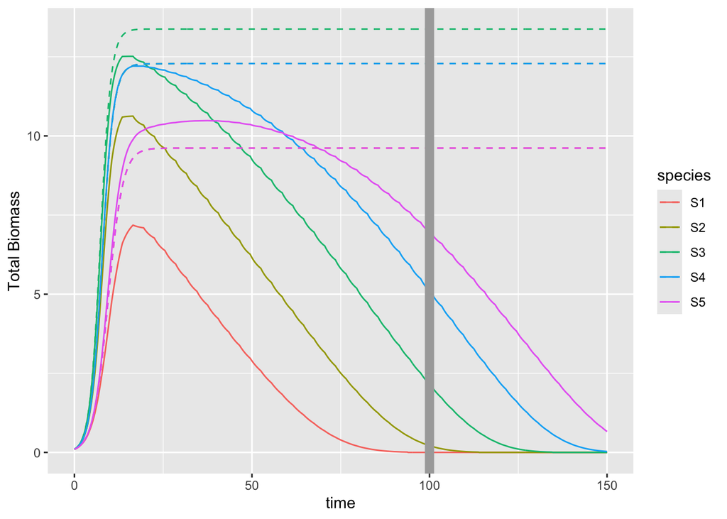